# PC gamers prefer playing free games: better games are free to play or a marketing strategy?

*By Luca Comba, Computer Science and Applied Statistics student.*

#### Platform for buying games have been around since 2003. Since then many games have become very popular around gamers. PC games have also been developed by multiple developers around the world that have been using different strategies for selling more copies. In the most recent years there has been a constant trend of the most played PC games being even free access for everyone. That brings the question if the price of PC games have a big impact on the popularity of the game itself.

#### PC game publishers most of the time make the game available for free, but most of the time, players will need to purchase extra item to personalized the gameplay of have advantages when playing online. We can see that more and more publishers are taking this marketing approach to get more users to download and play the game for free and then make a profit off of the add-ons that players can buy in the game.

Before Steam it was very common for developer to release a free demo of the game, so that the player could have tried the game before purchasing it. The distribution of free videogames’ demo was very popular since the early 1990, but then something changed.

Now PC games can be bought on steam and other platform, which made it easier for players to download and discover new games. This increased the video game market because more people would have access to a larger library of PC games and could have access to it anytime. PC games’ publisher companies have used different strategies to target gamers to purchase their PC games, but it seems that the most popular strategy is to simply make the game available for everyone with no cost. This strategy really paid off, because as we can see, in the the first graph, the most downloaded games are free games with the exception of a few games that are priced more than 20$. For high cost videogames we would presume that are more complex game and would have more complex single player story line. One example could be *Call of Duty* which they costs over 20$. *PLAYERUNKNOWN’S BATTLEGROUNDS* is the game that counts from 50 to 100 million owners and is a battle royale type of gameplay. The difference between other battle royle that are free to play in contrast with *PLAYERUNKNOWN’S BATTLEGROUNDS* is that the graphic seems more realistic. If we look at today’s Steam users’ reviews, in 2021, we would find a more mixed review which might be for the fact that the game was first published in 2017 and that many users complains about the presence of bots, which are used because of the low number of online players.

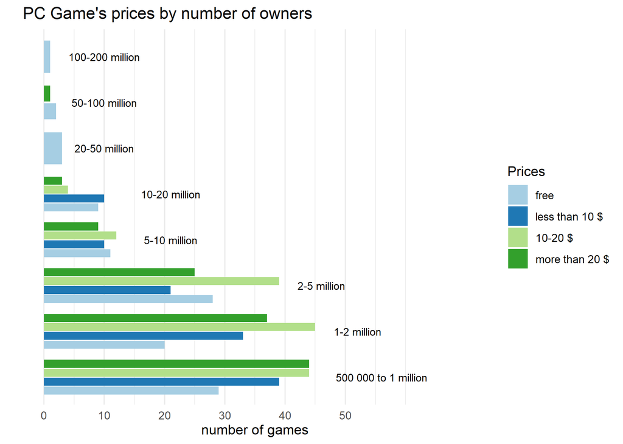

It is also interesting that games with 200 to 20 million owners they are mostly free and that players can only play online and where most of the times a marketplace is available for players to purchase extra add-in for the game in order to personalize it or unlock advanced items that the game offers. This strategy is very common for free games so that the customer is willing to download it for free, but eventually to unlock specific feature the player will need to pay for extra accessories. Another strategy for free games is the selling of DLC. For example, *Unturned* counts from 20 to 50 million users but DLC that would expand the gameplay can be also be purchased in the Steam store. In this game there is also the possibility of buying some extra items, like the *Mystery Box Key* with a cost of $0.99\$$, that would help the player to advance more rapidly or make the game more easier. So we can define a free game as a free to play game only if there would be no additional costs to advance in the game.

PC games that are counting less than 20 million owners can also be free to play games, but they become less common as the number of owners also decrease. This can be connected to the fact that less popular game are envisioned for a niche market. For example the game *Rome: Total War - Collection* that costs $12.99\$$ counts from 1 to 2 million owners and is categorized as a strategic historic game for which not all Steam users are interested in playing. In fact we can see that the distribution of price ranges in the games that have less than 20 million users are more spread out and gamers have a more vast range of prices.

Any of the Games that have been published in 2012 do not have reached more than 100 million owners yet. Although, games from 2012 are not as popular as other recent games, we can still that the most popular and played games are free to play while games that counts less owners can be priced to more than 20$.

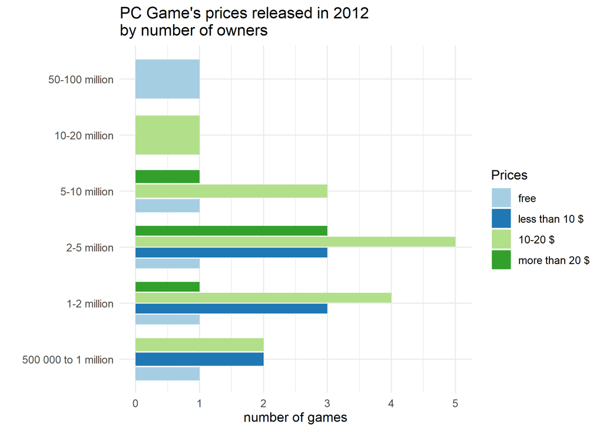

Games published in 2018 have not reached more than 100 million owners. Compared to the year of 2012, there have been published more games, but as usual, the most popular games are free to play. Another thing that comes up between the graph is that there have been more games with a price higher than 20$ in respect to 2012. Overall, in 2018 more games were published and the less downloaded games have been more expensive than the games published in 2012.

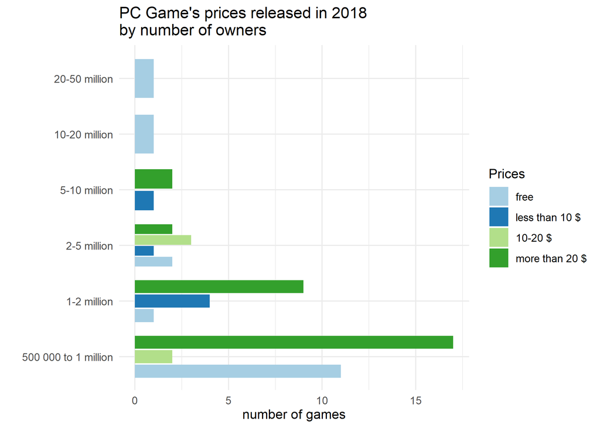

In conclusion we can notice that the trend of making a game download for free can make it more popular in respect with games that are not free. Players should pay attention to these marketing tactics, because free games will have methods of making the player pay for exclusive content and that way free to play games will become more expensive. Another important aspect of free to play games is that sometimes games are played by younger player that might not have the finance to buy safely extra items. Since 2012 we have seen, other then the increase in the game developed and published, also the growing of the market of free gaming which permits more players to get free games and play almost for free online.